# ggplot - Introduction

session 5b

Eviatar Guttman

Last updated: 18-05-2021

```r
library(tidyverse); library(patchwork)
```

# 1 introduction

`ggplot` היא כלי גרפי יוצא דופן בכך שיש לה תחביר והיא מאפשרת בניית גרפים באמצעות רכיבים עצמאיים.

רכיב גרפי עושה מיפוי (**mapping**) של **data** למאפיינים אסטטיים (גודל, צורה, צבע) של צורה גיאומטרית (נקודה, קו, bar).  
גרף גם יכול לכלול statistical transformations.  
לכל גרף יש **data** ויש את ה מיפוי ( **mapping** ) למאפיינים האסטטיים. המיפוי מגדיר כיצד המשתנים ב-data ימופו למה שאנחנו רואים.  
הרכיבים של ה-**mapping** הם:

1. **layer** - geometric elements and statistical transformations. geometrics like - points, lines and polygons. Statistical transformations that summarize the data.  
   Every plot has at least one layer which describes how to render each observation.
2. **scales** - a mapping from the data space to the aesthetic space - what we see in the color, shape,size, and legend.(what makespossible to read the original data values from the plot)
3. **coordinate system** - how data coordinates are mapped to the plane of the graphic - axes and gridlines. (we will use only Cartesian coordinate system)
4. **facet** - break up and display subsets of data.
5. **theme** - finer points of display, like the font size and background colour.

   טבלת הנתונים `mpg` כוללת נתוני צריכת דלק של רכבים

```r
head(mpg)
```

```
## # A tibble: 6 x 11
##   manufacturer model displ  year   cyl trans      drv     cty   hwy fl    class
##   <chr>        <chr> <dbl> <int> <int> <chr>      <chr> <int> <int> <chr> <chr>
## 1 audi         a4      1.8  1999     4 auto(l5)   f        18    29 p     compa~
## 2 audi         a4      1.8  1999     4 manual(m5) f        21    29 p     compa~
## 3 audi         a4      2    2008     4 manual(m6) f        20    31 p     compa~
## 4 audi         a4      2    2008     4 auto(av)   f        21    30 p     compa~
## 5 audi         a4      2.8  1999     6 auto(l5)   f        16    26 p     compa~
## 6 audi         a4      2.8  1999     6 manual(m5) f        18    26 p     compa~
```

`displ` זה נפח מנוע בליטרים. `hwy` זה מספר המיילים לגלון דלק.`fl` זה סוג הדלק

הפונקציה `ggplot` יוצרת מערכת קואורדינטות

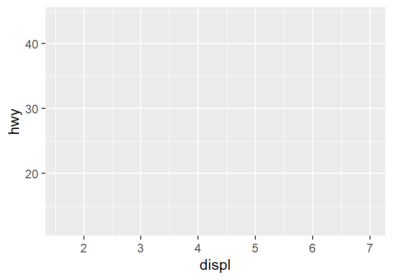

```r
ggplot(data = mpg, mapping =  aes(x = displ, y = hwy))
```

הפונקציה `geom_point` מוסיפה `layer` של נקודות (scatterplot) לגרף.

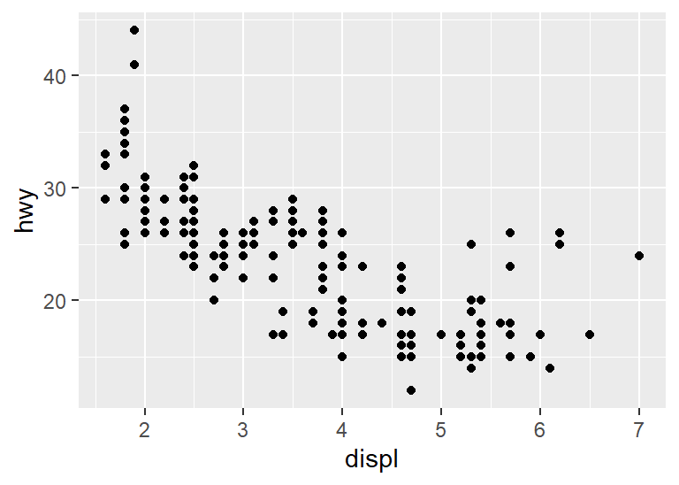

```r
ggplot(data = mpg, mapping =  aes(x = displ, y = hwy))  +
  geom_point()
```

מוסיפים `layers` באמצעות הסימן `+` אשר מגיע בסוף שורה.

אפשר לקצר בכתיבה ולהשמיט את ה-`mapping`, `y=`, `x=`

```r
ggplot(mpg, aes(displ, hwy)) +
  geom_point()
```

הוספת aesthetics עובדת באותו אופן כמו הארגומנטים x ו-y. מוספים אותו בתוך הפונקציה `aes`.  
נוסיף את המשתנה `class` לתרשים ונקצה אותו ארגומנט ה-`color`:

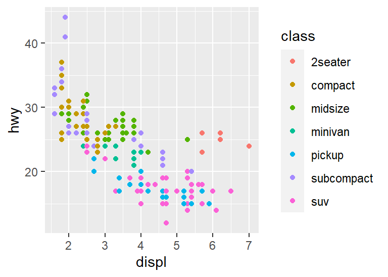

```r
ggplot(mpg, aes(displ, hwy, color = class)) +
  geom_point()
```

`ggplot` מקצה ערך ייחודי לכל ערך במשתנה (במקרה זה צבע). פעולה זו נקראת **scaling** והפונקציה האחראית לפעולה זו נקראת `scale`.  
בנוסף, פונקציית ה-`scale` אחראית גם ליצירת ה-guide: ציר x או y, או legend המאפשרים לנו להבין את הגרף. זו פעולה הפוכה הלוקחת נתונים ממרחב גרפי בחזרה לערכי data.  
בדוגמא, ה-`scale` הוסיף את ה-legend המסביר לנו לאיזה class של רכב כל צבע מופה.

דוגמאות נוספות :

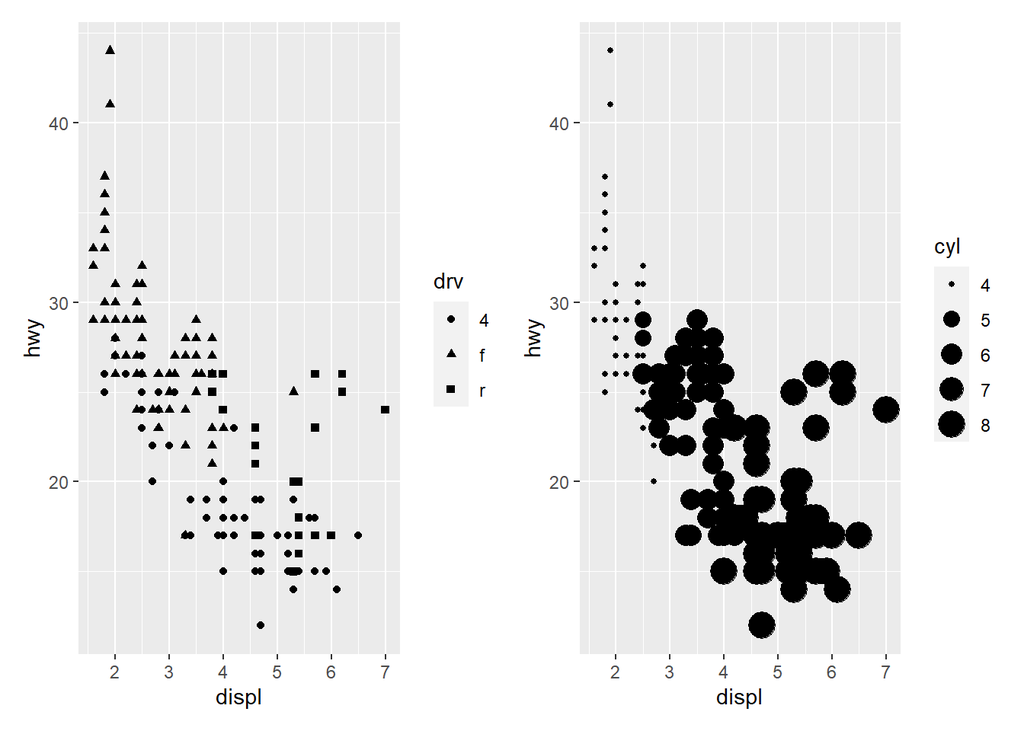

```r
p2 <- ggplot(mpg, aes(displ, hwy, shape = drv)) +
  geom_point()

p3 <- ggplot(mpg, aes(displ, hwy, size = cyl)) +
  geom_point()

p2 + p3
```

מיפוי של משתנה לא סדור ל-aesthetic סדור זה לא רעיון טוב:

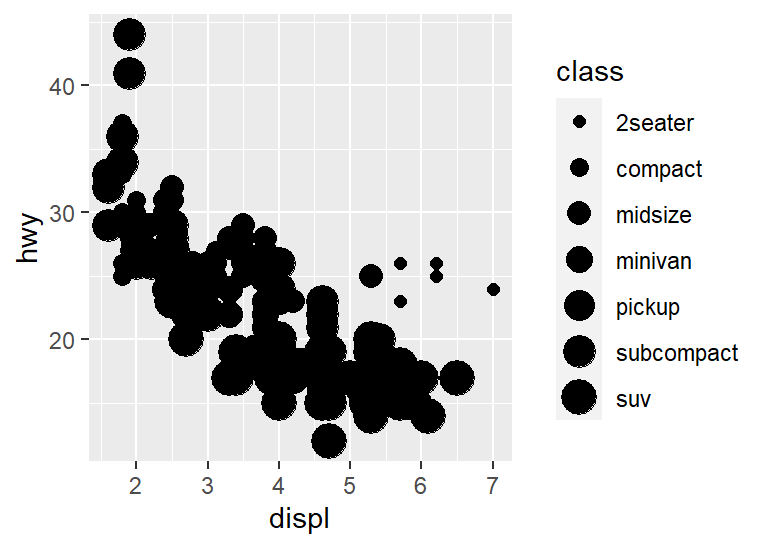

```r
ggplot(mpg, aes(displ, hwy, size = class)) +
  geom_point()
```

כדי לקבע aesthetic לערך יחיד ללא `scaling` הכנס אותו מחוץ לפונקציה `aes`.

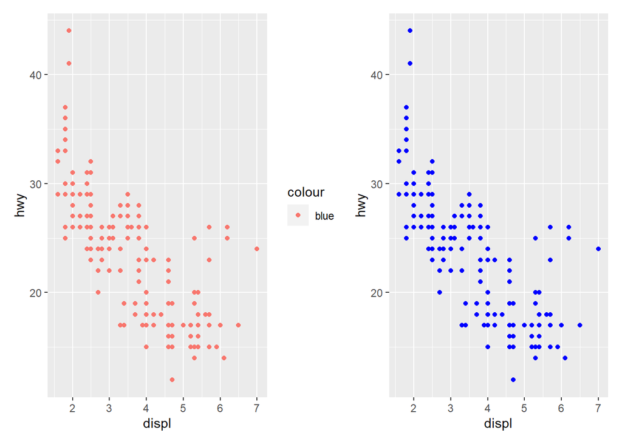

```r
p1 <- ggplot(mpg, aes(displ, hwy)) + geom_point(aes(colour = "blue"))
p2 <- ggplot(mpg, aes(displ, hwy)) + geom_point(colour = "blue")
p1 + p2
```

# 2 Geometric objects

`geom_smooth` מתאים קו מגמה למודל ומציג אותו עם סטיית תקן

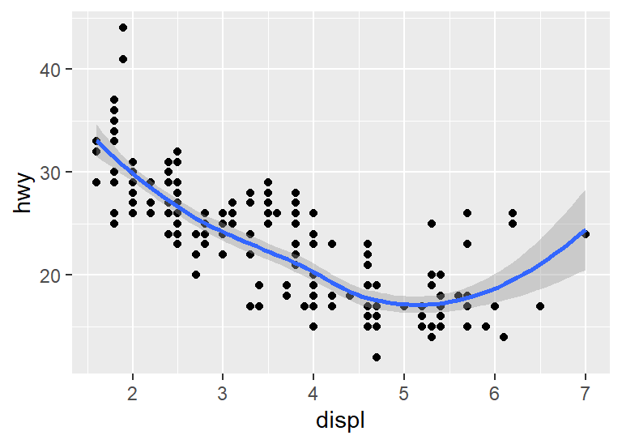

```r
ggplot(mpg, aes(displ, hwy)) +
  geom_point() +
  geom_smooth()
## `geom_smooth()` using method = 'loess' and formula 'y ~ x'
```

לא כל aesthetic עובד עם כל geom. אפשר לשנות הצורה של נקודה, אך לא ניתן לשנות צורה של קו. אפשר לשנות את סוג הקו.

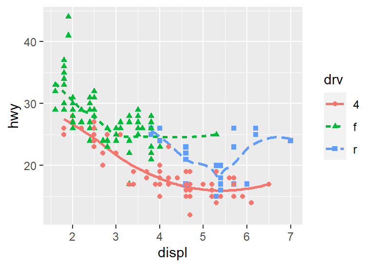

```r
ggplot(mpg, aes(displ, hwy, color = drv)) +
  geom_smooth(aes(linetype = drv), se = F) +
  geom_point(aes(shape = drv))
## `geom_smooth()` using method = 'loess' and formula 'y ~ x'
```

כאשר מזינים ארגומנטים ב-mapping של הפונקציה ggplot, הן יהיו כלליות וייושמו על כל geom בגרף. כאשר מזינים ארגומנטים ב-mapping של ה-geom, הם יהיו תקפים רק לאותו layer. מה שהוזן ב-geom ירחיב או ישכתב את ההוראות הכלליות. זה מאפשר להציג aesthetics שונים ב-layers שונים.  
בדוגמא: קו הרגרסיה מציג חלק מטבלת הנתונים `mpg` רק עבור מכוניות בקטגוריית subcompact.

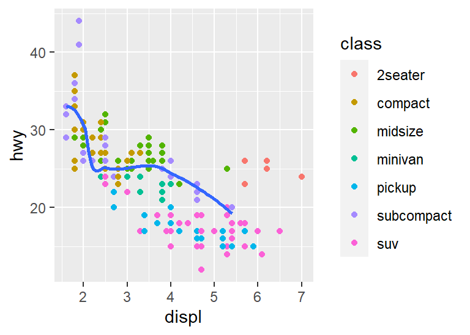

```r
ggplot(data = mpg, aes(x = displ, y = hwy)) +
  geom_point(aes(color = class)) +
  geom_smooth(data = filter(mpg, class == "subcompact"), se = FALSE)
## `geom_smooth()` using method = 'loess' and formula 'y ~ x'
```

`geom_path` ו- `geom_line` מציירים קווים בין נקודות data. קווים בד"כ משמשים כדי להציג שינוי לאורך זמן.  
`path` מחבר נקודות לפי הסדר שהם מופיעים בנתונים. הקו יכול ללכת בכל כיוון.

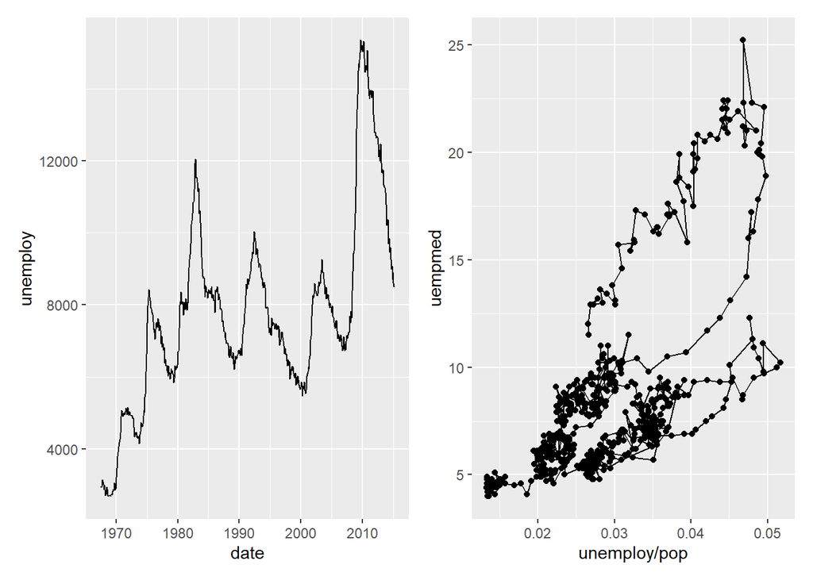

```r
p1 <- ggplot(economics, aes(date, unemploy)) + geom_line()

p2 <- ggplot(economics, aes(unemploy / pop, uempmed)) +
  geom_path() +  geom_point()

p1 + p2
```

`geom_boxplot` מסכם את הצורה של התפלגות עם קומץ סטטיסטיים

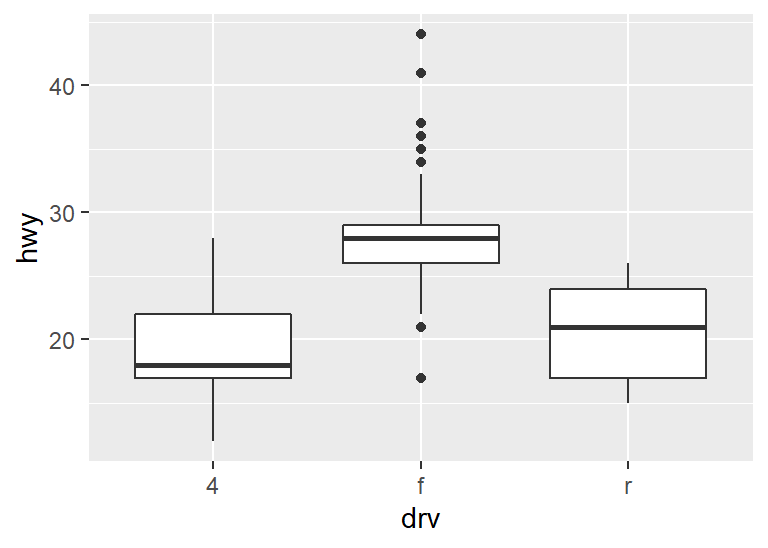

```r
ggplot(mpg, aes(drv, hwy)) + geom_boxplot()
```

ב-ggplot יש למעלה מ-40 geoms. חבילות המרחיבות את ggplot מספקות אף יותר.